# Algoritma Academy: Time Series & Forecasting

### 2.6.2 Forecast using Holt-Winters

Making a forecast is simple enough in R using the `forecast` function. Let’s try forecast with 24 more months (`h=24`):

[figure not shown]

```r
souv_hwf <- forecast(souv_hw, h=24)
plot(souv_hwf)
```

We obtain the forecast (blue line) with a 80% (dark grey) and 95% (light grey) prediction intervals, respectively. We’ll also check that the predictive model cannot be improved upon by observing if the in-sample forecast errors show non-zero autocorrelations at lag 1-20 and performing the Ljung-Box test:

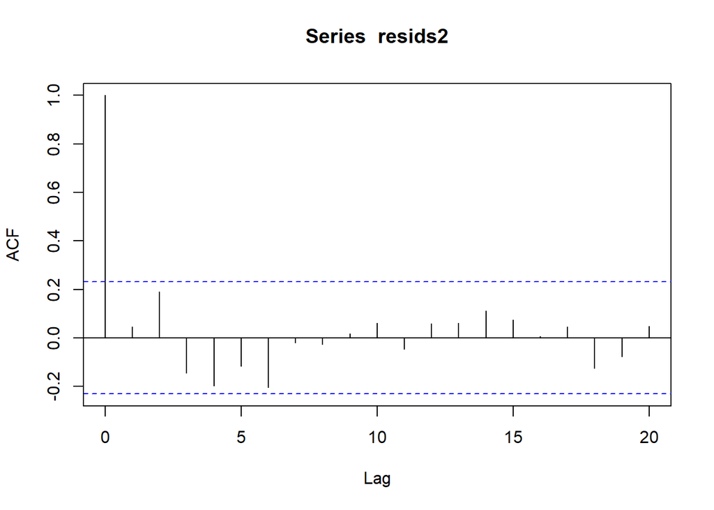

```r
resids2 <- souv_hwf$residuals[!is.na(souv_hwf$residuals)]
acf(resids2, lag.max=20)
```

```r
Box.test(resids2, lag=20, type="Ljung-Box")
```

```
##
##  Box-Ljung test
##
## data:  resids2
## X-squared = 17.53, df = 20, p-value = 0.6183
```

The correlogram shows that the autocorrelations for the in-sample forecast errors do not exceed the significance bounds for lags 1-20. Furthermore, the p-value from our Ljung-Box test is 0.62, indicating that there is little evidence of a non-zero autocorrelations at lags 1-20. We’ll also use a time plot to check that the forecast errors follow a normal distribution with mean zero and roughly constant variance:

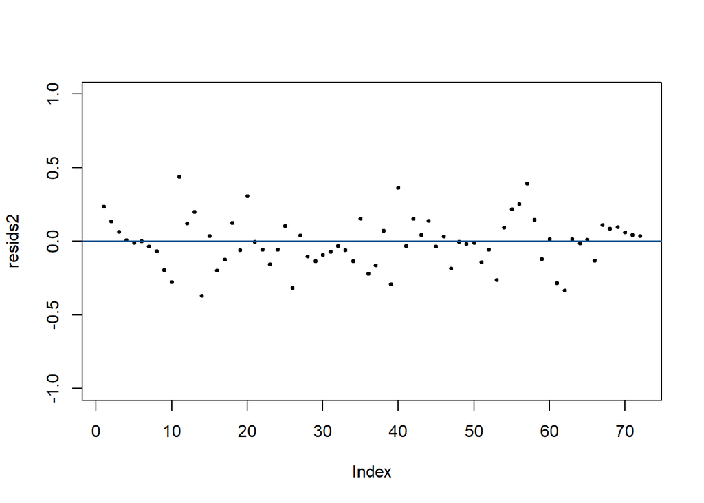

```r
plot(resids2, pch=19, cex=0.5, ylim=c(-1, 1))
abline(h=0, col="dodgerblue4")
```

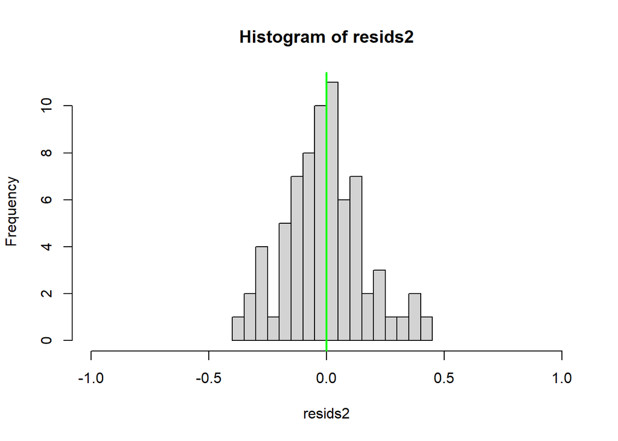

```r
hist(resids2, breaks=15, xlim=c(-1, 1))
abline(v=0, lwd=2, col="green")
```

It appears plausible from both our plots that the forecast errors do follow these assumptions – combined with the Ljung-Box test and acf plot, we may say that the Holt-Winters exponential smoothing appear to provide an adequate predictive model for the log of sales at the souvenir shop and cannot be improved upon.

## 2.7 ARIMA Models

### 2.7.1 Stationarity and Differencing

An important concept when dealing with time series is the idea of stationarity. A stationary time series is one whose **properties** do not depend on the time at which the series is observed, so a time series with trends or seasonality are not stationary - the trend and seasonality will affect the value of the time series at different times. A white noise series on the other hand is stationary.

Some cases can be less clear-cut: a time series with cyclic behavior (but not trend or seasonality) is stationary. This is because the cycles are not of fixed length so before we observe the series we cannot be sure where the peaks and troughs of the cycles will be. In general, a stationary time series will have no predictable patterns in the long term and their plots will show roughly constant variance.

Quiz: Which of the three time series are stationary?

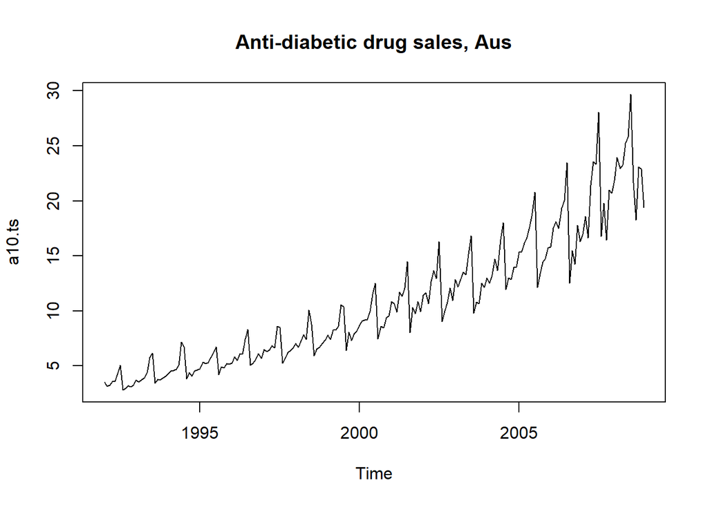

```r
library(fpp)
#op <- par(mfrow=c(2,2), pty="s", mar=c(0,0,0,0))

a10.ts <- ts(a10, frequency = 12, start=c(1992,1))
debit.ts <- ts(debitcards, frequency = 12, start=c(2000,1))
wmurders.ts <- ts(wmurders, frequency = 12, start=c(1950,1))

#par(mfrow=c(4,1))
plot(a10.ts)
title("Anti-diabetic drug sales, Aus")
```

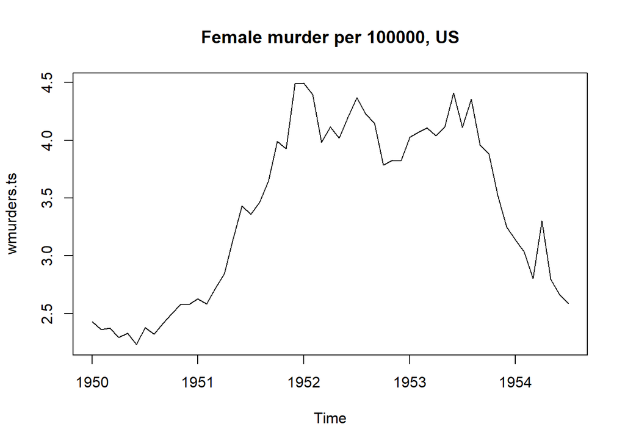

```r
plot(wmurders.ts)
title("Female murder per 100000, US")
```

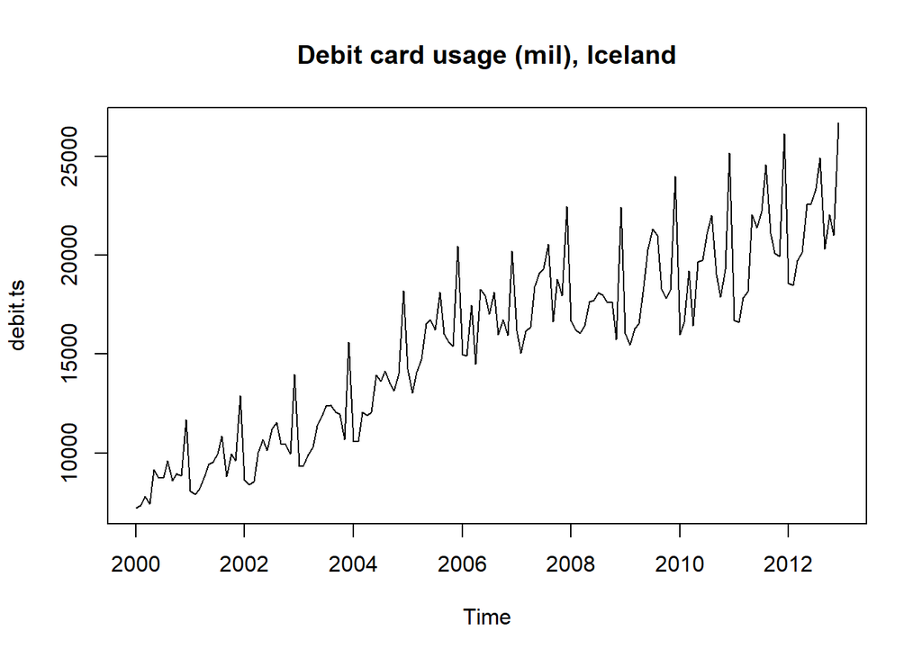

```r
plot(debit.ts)
title("Debit card usage (mil), Iceland")
```

```r
# end of plotting, reset to previous settings
#reset_par()
```

Obvious seasonality rules out the debit card usage time series and anti-diabetic drug sales, while trend rules out female murder rate series. In addition to seasonality, increasing variance in the anti-diabetic drug sales series also violated the assumptions required for stationarity.

Let’s take the anti-diabetic drug sales series and see if we can make it stationary: a common technique that springs to mind is to deal with non-constant variance by taking the logarithm or square root of the series, so we’ll try that.

Apart from taking the log, another common technique to deal with non-stationary data is to difference the data. That is, given the series $Z_t$, create the new series:  
$Y_i = Z_i - Z_{i-1}$

The differenced data will contain one less point than the original data. Although we can difference the data more than once, one difference is usually sufficient.

See `diff()` in action:

```r
prices <- c(10, 4, 17, 3, 1)
diff(prices)
```

```
## [1]  -6  13 -14  -2
```

Let’s plot the original diabetic drug sales series, the log-transformed series, and the differenced series:

[figure not shown]

```r
par(mfrow=c(3,1))
plot(a10.ts)
plot(log(a10.ts))
plot(diff(log(a10.ts), lag=12), xlab="Year")
```

Transformations such as logarithms help to stabilize the variance of a time series and techniques such as differencing (compute differences between consecutive observations) help stabilize the mean of a time series by removing changes in the level of a time series and so eliminating trend and seasonality.

Another technique that is helpful is the ACF plot we’ve learned about earlier: **The ACF of a stationary time series will drop to zero relatively quickly** while the ACF of a non-stationary data decreases slowly:

[figure not shown]

```r
par(mfrow=c(1,2))
acf(a10.ts)
acf(diff(log(a10.ts), lag=12))
```

**Second-order differencing and Seasonal differencing**:  
Occasionally the differenced data will not appear stationary and it may be necessary to difference the data a second time to obtain a stationary series. In this case we are modeling the “change in the changes” of the original data - in practice, it is almost never necessary to go beyond second-order differences.

Second order differencing:

```r
prices <- c(10, 4, 17, 3, 1)
prices
```

```
## [1] 10  4 17  3  1
```

```r
diff(prices)
```

```
## [1]  -6  13 -14  -2
```

```r
diff(diff(prices))
```

```
## [1]  19 -27  12
```

Seasonal difference is the difference between an observation and the corresponding observation from the previous season, and are also called “lag-m differences” as we subtract the observation after a lag of *m* periods.

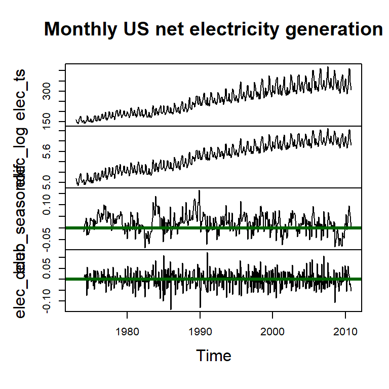

```r
elec_ts <- ts(usmelec, frequency=12, start=c(1973,1))
elec_log <- log(elec_ts)
elec_seasondif <- diff(log(elec_ts), lag=12)
elec_doub <- diff(elec_seasondif, lag=1)

elec.df <- ts(data.frame(
  cbind(elec_ts, elec_log, elec_seasondif, elec_doub)
), frequency=12, start=c(1973,1))
plot.ts(elec.df, plot.type="m", main="Monthly US net electricity generation", panel = function(x, col, bg, pch, type, ...){
  lines(x=x, col=col)
  abline(h=0, col="darkgreen", lwd=3)})
```

Sometimes it is necessary to do both a seasonal difference and a first difference to obtain stationary data as shown in the panel above. When both seasonal and first differences are applied it makes no difference which is done first as the result will be the same. However, if the data have a strong seasonal pattern, it is recommended that seasonal differencing be done first because sometimes the resulting series will be stationary and there will be no need for a further first difference.

**Stationarity Testing**

**1. ADF Test**

*The Augmented Dickey-Fuller (ADF)* test is a statistical test commonly used to test for the presence of a unit root in a time series. A unit root is a characteristic of a time series process where the mean and variance of the series increase over time and the series does not converge to a constant value, making it non-stationary.

The null-hypothesis for an ADF test is that the data are non-stationary, so large p-values are indicative of non-stationarity and **small p-values suggest stationarity**. Using the usual 95% threshold, differencing is required if the p-value is greater than 0.05.

```r
adf.test(elec_ts, alternative = "stationary")
```

```
##
##  Augmented Dickey-Fuller Test
##
## data:  elec_ts
## Dickey-Fuller = -9.9254, Lag order = 7, p-value = 0.01
## alternative hypothesis: stationary
```

```r
adf.test(souvenir_ts, alternative = "stationary")
```

```
##
##  Augmented Dickey-Fuller Test
##
## data:  souvenir_ts
## Dickey-Fuller = -2.0809, Lag order = 4, p-value = 0.5427
## alternative hypothesis: stationary
```

**2. KPSS Test**

Another way to determine more objectively if differencing is required is to use a the *Kwiatkowski Phillips Schmidt and Shin test (KPSS) test* test. That based on linear regression which breaks the time series into deterministic trend, random walk, and stationary error.

KPSS test is contrary to ADF test to test stationarity the null-hypothesis for an KPSS test is that the data are stationary, so **large p-values are indicative of stationarity** and small p-values suggest no-stationarity. Using the usual 95% threshold, differencing is required if the p-value is less than 0.05.

```r
kpss.test(elec_ts)
```

```
##
##  KPSS Test for Level Stationarity
##
## data:  elec_ts
## KPSS Level = 7.5248, Truncation lag parameter = 5, p-value = 0.01
```

```r
kpss.test(souvenir_ts)
```

```
##
##  KPSS Test for Level Stationarity
##
## data:  souvenir_ts
## KPSS Level = 1.3089, Truncation lag parameter = 3, p-value = 0.01
```

Both tests are used to test stationarity, but in some cases they both give contradictory results. There are 4 possible combinations of KPSS and ADF test results.

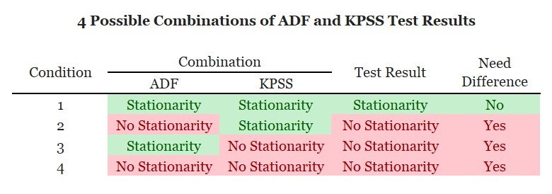

There are many cases where both give contradicting results, so we follow a rule[^9]:

> Neither the ADF test nor the KPSS test will confirm or disconfirm stationarity in isolation. Run both tests to decide if you should difference. **If a least one of the tests claims to have found no-stationarity, you should difference**.

**Discuss:** From the two time series, Are they stationary? How would you transform the time series into one that is stationary? Use the ADF & KPSS Test to confirm that your transformed time series is in fact now stationary:

```r
### Your answer below:
```

### 2.7.2 Autoregressive models

Recall from our regression models class that a multiple regression model “forecast” the variable of interest using a linear combination of predictors. In an autoregressive model, we forecast the variable of interest using a linear combination of *past values of the variable*. The term autoregression indicates that it is a regression of the variable against itself, just as the term autocorrelation refers to the practice of performing correlation on a time series against itself. Personally, I find it easier to think of the term “auto” in both cases as in “autonomous” rather than “automatic”.

Given that definition, an autoregression model of order *p* can be described as:  
$y_t = c + \phi_1y_{t-1} + \phi_2y_{t-2} + ... + \phi_py_{t-p}+e_t$

Where c is a constant and e is white noise. This is like a multiple regression but with lagged values of $y_t$ as predictors. We refer to this as an AR(p) model. Note that changing the parameters $\phi_1, ... \phi_p$ will result in different time series patterns, and also that the variance of the error term $e_t$ will only change the scale of the series but not the patterns.

For an AR(1) model:  
- When $\phi_1 = 0$, $y_t$ is equivalent to white noise ($c+e_t$) - When $\phi_1 = 1$ and $c=0$, $y_t$ is equivalent to a random walk

We normally restrict autoregressive models to stationary data and then some constraints on the values of the parameters are required:  
- For an AR(1) model: $-1 \leq \phi_1 < 1$  
- For an AR(2) model: $-1 \leq \phi_2 < 1$, $\phi_1 + \phi_2 < 1$, $\phi_1 - \phi_2 < 1$

To see an example of AR in action, we’ll use the time series for monthly total generation of electricity. The length of our time series is 454, and `ar()` will select the optimal value of order if we don’t specify a maximum order by using the optional `order.max` parameter:

```r
elec_ar <- ar(elec_ts)
elec_ar
```

```
##
## Call:
## ar(x = elec_ts)
##
## Coefficients:
##       1        2        3        4        5        6        7        8
##  0.9307  -0.0796   0.0169  -0.1177   0.1437   0.0353   0.0497  -0.0769
##       9       10       11       12       13       14       15       16
## -0.0105   0.0651  -0.0349   0.4881  -0.4270   0.0349  -0.1109   0.1631
##      17       18       19       20       21       22       23       24
## -0.0370  -0.1711   0.0755   0.0337  -0.0407  -0.0034   0.0604   0.2555
##      25
## -0.2533
##
## Order selected 25  sigma^2 estimated as  143.1
```

When p >= 3, the restrictions are much more complicated - fortunately R takes care of these restrictions when estimating a model.

### 2.7.3 Moving average models

Rather than using past values of the forecast variable in a regression, a moving average model uses past forecast errors in a regression-like model:  
$y_t = c + e_t + \theta_1e_{t-1} + \theta_2e_{t-2} + ... + \theta_qe_{t-q}$  
Where $e_t$ is white noise. We refer to this as an MA(q) model. Notice that each value of $y_t$ can be thought of as a weighted moving average of the past few forecast errors.

### 2.7.4 Non-seasonal ARIMA models

If we combine differencing, autoregression and a moving average model, we obtain a non-seasonal ARIMA model. The AR part of ARIMA indicates that the evolving variable of interest is regressed on its own lagged values while the MA part indicates that the regression error is actually a linear combination of error terms whose values occured contemporaneously and at various times in the past. The I (for “integrated”) indicates that the data values have been replaced with the difference between their values and the previous values (and this differencing process may have been performed more than once, even though in practice it’s rarely necessary to have more than 2 levels of differencing before a white noise series is obtained). The purpose of each of these features is to make the model fit the data as well as possible.

Non-seasonal ARIMA models are generally denoted ARIMA(p,d,q) where parameters p,d, and q are non-negative integers. - p is the order (number of time lags) of the AR model  
- d is the degree of differencing (number of times the data have had past values subtracted)  
- q is the order of the moving-average model

ARIMA(1,0,0) is AR(1); ARIMA(0,1,0) is I(1), and ARIMA(0,0,1) is MA(1).

Selecting appropriate values for p, d and q can be difficult but fortunately for us the `auto.arima()` function will do it for us.

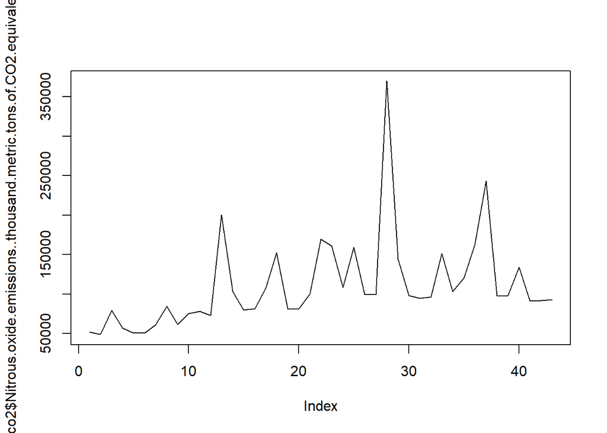

```r
plot(co2$Nitrous.oxide.emissions..thousand.metric.tons.of.CO2.equivalent., type="l")
```

We’ll first create a time series object using observations from that data frame, specifying the `start` and `frequency`:

```r
agri_ts <- ts(co2$Nitrous.oxide.emissions..thousand.metric.tons.of.CO2.equivalent., start=1970, frequency=1)
```

And use `auto.arima` on the time series, and since we’ve observed earlier that there seems to be no seasonal pattern, we’ll restrict the search to non-seasonal models using `seasonal=F`:

```r
agri_arima <- auto.arima(agri_ts, seasonal=F)
agri_arima
```

```
## Series: agri_ts
## ARIMA(0,1,1)
##
## Coefficients:
##           ma1
##       -0.8244
## s.e.   0.0842
##
## sigma^2 = 3210286376:  log likelihood = -519.34
## AIC=1042.68   AICc=1042.99   BIC=1046.16
```

The output of `auto.arima` suggests an ARIMA(0,1,1), so that’s equivalent to a one-order differencing with a MA(1) model.

**Discussion:** `usconsumption` is a multivariate time series measuring percentage changes in quarterly personal consumption expenditure and personal disposable income for the US from 1970 to 2010:

```r
head(usconsumption)
```

```
##         consumption    income
## 1970 Q1   0.6122769  0.496540
## 1970 Q2   0.4549298  1.736460
## 1970 Q3   0.8746730  1.344881
## 1970 Q4  -0.2725144 -0.328146
## 1971 Q1   1.8921870  1.965432
## 1971 Q2   0.9133782  1.490757
```

When we plot the multivariate time series, we’ll see the following pattern:

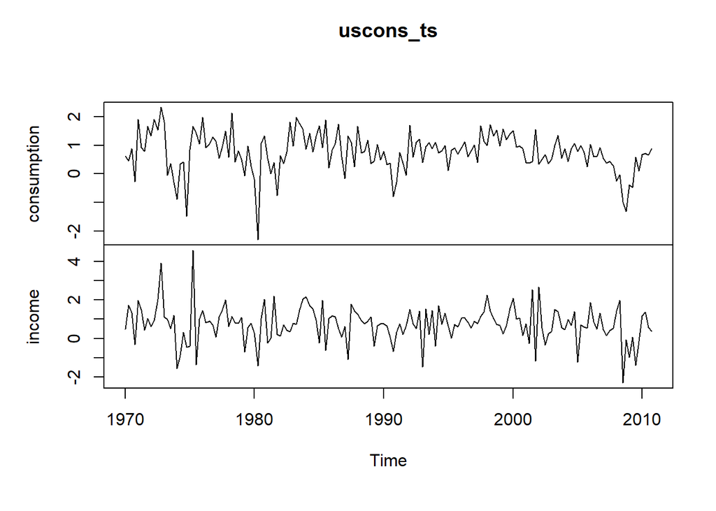

```r
uscons_ts <- ts(usconsumption, start = c(1970,1), frequency = 4)
plot(uscons_ts)
```

1. Do you think the time series is stationary? (Hint: I mentioned earlier that it is the percentage changes in quarterly PCE and PDI, strongly suggesting that it is a differenced series)
2. Is the time series seasonal?
3. If the time series is stationary (Question 1), what do you think the value of *I* would be in ARIMA?

Observe from the plot (quarterly percentage changes in US consumption expenditure and income) above - there appears to be no seasonal pattern so we will fit a non-seasonal ARIMA model:

```r
uscons.arima <- auto.arima(uscons_ts[,1], seasonal=F)
uscons.arima
```

```
## Series: uscons_ts[, 1]
## ARIMA(0,0,3) with non-zero mean
##
## Coefficients:
##          ma1     ma2     ma3    mean
##       0.2542  0.2260  0.2695  0.7562
## s.e.  0.0767  0.0779  0.0692  0.0844
##
## sigma^2 = 0.3953:  log likelihood = -154.73
## AIC=319.46   AICc=319.84   BIC=334.96
```

The result suggested an ARIMA(0,0,3) model, recall this is equivalent to a MA(3) model:  
$y_t = 0.7562 + e_t + 0.2542e_{t-1} + 0.2260e_{t-2} + 0.2695e_{t-3}$  
where 0.7562 is the constant term and $e_t$ is white noise with standard deviation 0.62 (or: sqrt(0.3953)).

[figure not shown]

```r
plot(forecast(uscons.arima, h=10), include=100)
```

To tell whether values of p and q chosen are appropriate for the time series we can try applying the ACF and PACF plot. Recall that an ACF plot shows the autocorrelations which measures the relationship between $y_i$ and $y_{t-k}$, now if $y_t$ and $y_{t-1}$ are correlated then $y_{t-1}$ and $y_{t-2}$ must also be correlated. But then $y_t$ and $y_{t-2}$ may be correlated simply because they are both connected to $y{t-1}$ rather than because of any new information that can be useful to our forecast model.

To overcome this problem, we use **partial autocorrelations** to help us measure the relationship between $y_t$ and $y_{t-k}$ after removing the effects of other lags between t and k.

[figure not shown]

```r
Pacf(uscons_ts[,1], main="")
```

The partial autocorrelations have the same critical values of $\pm1.96/ \sqrt{T}$ where T is the number of points in the time series. In here, the critical values are 0.15 and -0.15 respectively.

```r
1.96/sqrt(length(uscons_ts[,1]))
```

```
## [1] 0.1530503
```

```r
-1.96/sqrt(length(uscons_ts[,1]))
```

```
## [1] -0.1530503
```

Observe the pattern in the first three spikes from the PACF plot - this is what we would expect from an ARIMA(0,0,3) as the PACF tends to decay exponentially. In this case, the PACF lead us to the same model as the automatic procedure we perform using `auto.arima` above (both suggested ARIMA(0,0,3)).

How `auto.arima` works behind the scene is a combination of KPSS tests for choosing the parameter *d* and choosing p and q to minimize the AIC - the details of which is beyond the scope of this coursebook. However, if you want to fit a model using your own parameters, you can do so using the `Arima()` function. To fit a `ARIMA(0,0,3)` model to the US consumption data:

```r
uscons_arima2 <- Arima(uscons_ts[,1], order=c(0,0,3))
uscons_arima2
```

```
## Series: uscons_ts[, 1]
## ARIMA(0,0,3) with non-zero mean
##
## Coefficients:
##          ma1     ma2     ma3    mean
##       0.2542  0.2260  0.2695  0.7562
## s.e.  0.0767  0.0779  0.0692  0.0844
##
## sigma^2 = 0.3953:  log likelihood = -154.73
## AIC=319.46   AICc=319.84   BIC=334.96
```

This gives us exactly the same result as the `auto.arima()` function call we made above.

Let’s summarize the general approach to fitting an ARIMA model:  
1. Plot the data; Identify any unusual observations  
2. If necessary, transform the data (Box-Cox Transformation) to stabilize the variance  
3. If data are non-stationary, take first differences of the data until data are stationary  
4. Examine the ACF / PACF: Is an AR(p) or MA(q) model appropriate?  
5. Try your chosen model(s)  
6. Check the residuals from our models by plotting the ACF of the residuals - they have to look like white noise  
7. If residuals look like white noise, calculate forecasts

The automated algorithm only takes care of steps 3-5, so we’ll have to do the rest manually!

### 2.7.5 Seasonal ARIMA models

ARIMA models are also capable of modelling seasonal data. A seasonal ARIMA model is formed by including additional seasonal terms in the ARIMA model we have seen and discussed so far.

Seasonal ARIMA models are usually denoted $ARIMA(p,d,q)(P,D,Q)_m$ where *m* refers to the number of periods in each season, and the uppercase P,D,Q refers to the autoregressive, differencing and moving average terms for the seasonal part of the ARIMA model. Notice that as a convention, we use uppercase notation for the seasonal parts of the model and lowercase for the non-seasonal parts.

The seasonal part of an AR or MA model will be seen in the seasonal lags of the PACF and ACF. For example, an $ARIMA(0,0,0)(0,0,1)_{12}$ model will show:  
- a spike at lag 12 in the ACF but no other significant spikes  
- exponential decay in the seasonal lags of the PACF; that is, at lags 12, 24, 36…

Similarly, an $ARIMA(0,0,0)(1,0,0)_{12}$ model will show:  
- exponential decay in the seasonal lags of the ACF  
- a significant spike at lag 12 in the PACF

In considering the appropriate seasonal orders for an ARIMA model, restrict attention to the seasonal lags. The modelling procedure is almost the same as for non-seasonal data, except that we need to select seasonal AR and MA terms as well as the non-seasonal components of the model. Let’s see some examples:

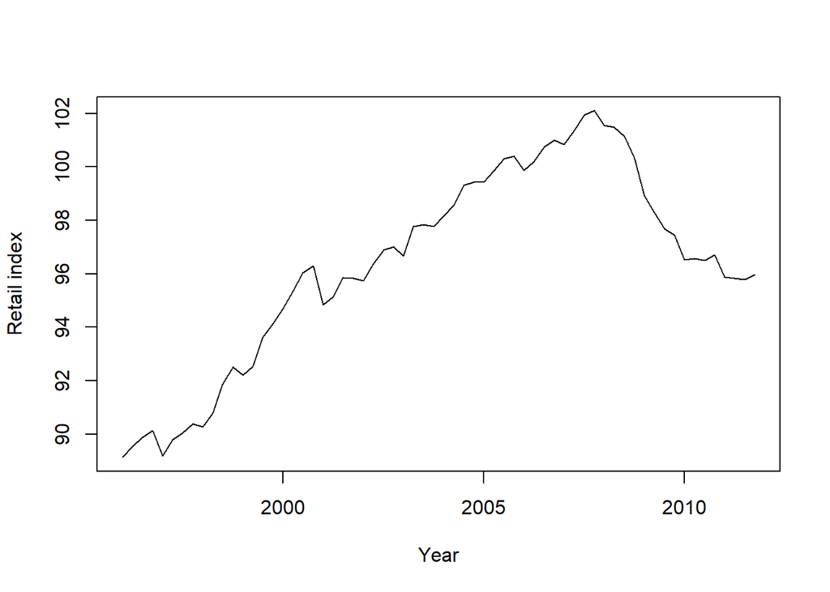

```r
plot(euretail, ylab="Retail index", xlab="Year")
```

This is a plot of the quarterly retail trade index in the Euro area covering wholesale and retail trade and repair of motor vehicles. The data is clearly non-stationary with some seasonality, so let’s take a seasonal difference and plot the seasonally differenced data:

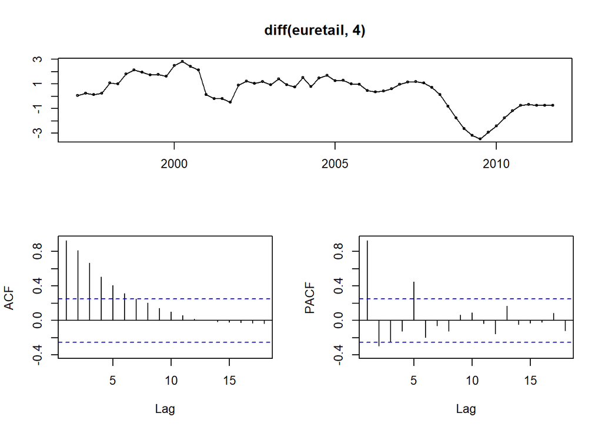

```r
tsdisplay(diff(euretail, 4)) # quarterly differenced
```

The data still appear to be non-stationary so we take an additional first difference:

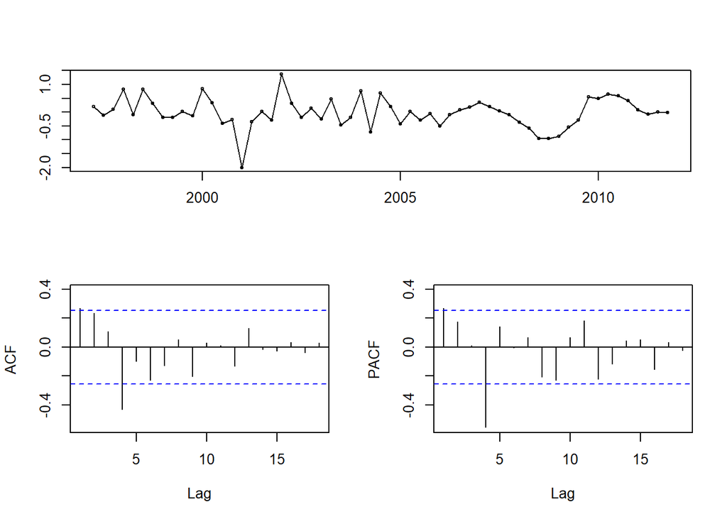

```r
tsdisplay(diff(diff(euretail,4),1), main="")
```

Our aim now is to find an appropriate ARIMA model based on the ACF and PACF shown. The significant spike at lag 1 in the ACF and PACF suggests a non-seasonal MA(1) component, and the significant spike at lag 4 (and to a lesser extent at lag 8, lag 12, lag 16) in the PACF suggest a seasonal MA(1) component. Consequently, we begin with an $ARIMA(0,1,1)(0,1,1)_4$ model, indicating a first and seasonal difference, and non-seasonal and seasonal MA(1) components. The residuals for the fitted model are:

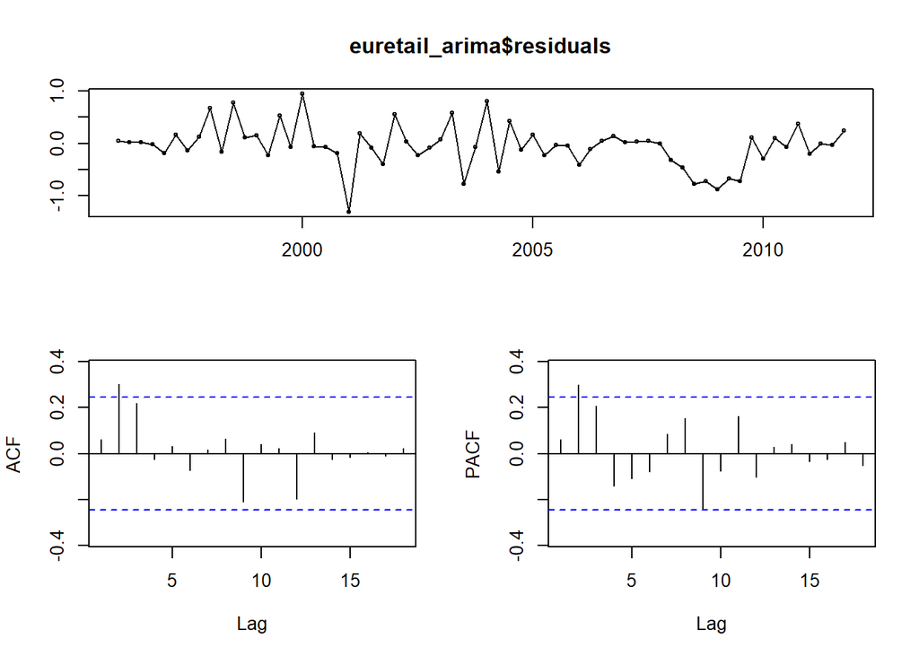

```r
euretail_arima <- Arima(euretail, order=c(0,1,1), seasonal=c(0,1,1))
tsdisplay(euretail_arima$residuals)
```

Both the ACF and PACF show significant spikes at lag 2, and almost significant spikes at lag 3, indicating some additional non-seasonal terms need to be included in the model. Using the Ljung-Box test we try a few other models and arrive at a lowest AIC value with the $ARIMA(0,1,3)(0,1,1)_4$ model:

```r
euretail_final <- Arima(euretail, order=c(0,1,3), seasonal=c(0,1,1))

Box.test(euretail_final$residuals, lag=16, type="Ljung")
```

```
##
##  Box-Ljung test
##
## data:  euretail_final$residuals
## X-squared = 7.0105, df = 16, p-value = 0.9731
```

Now that we have a seasonal ARIMA model that passes the required checks, we’ll plot the forecasts from the model for the next 3 years. Notice that the forecasts follow the recent trend in the data:

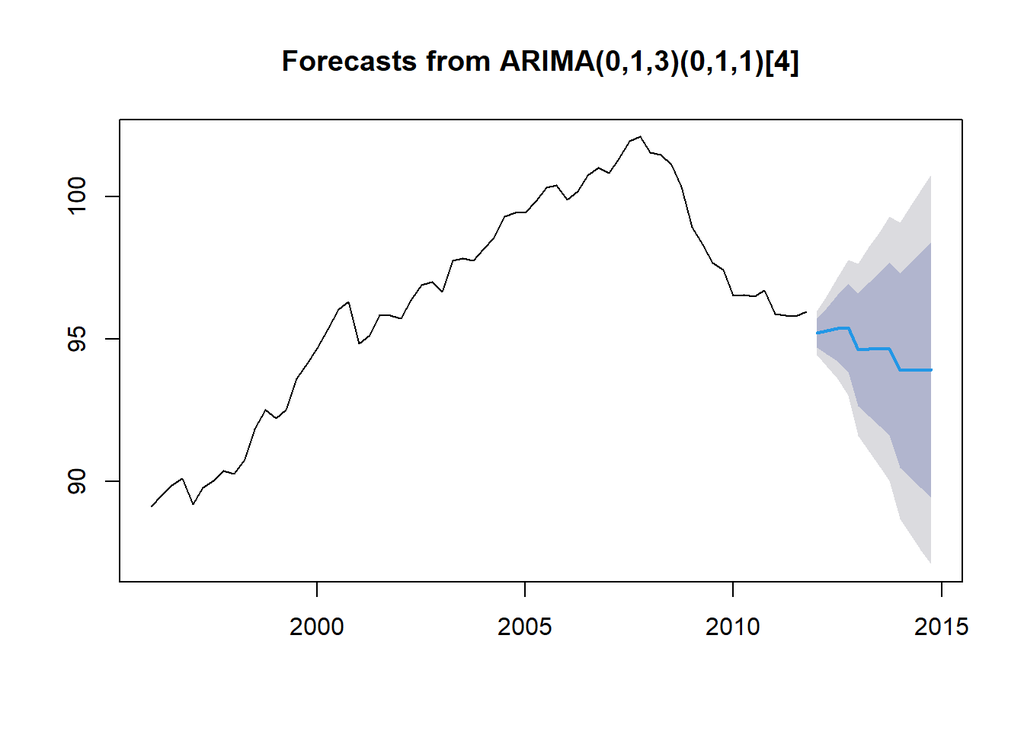

```r
plot(forecast(euretail_final, h=12))
```

```r
auto.arima(euretail)
```

```
## Series: euretail
## ARIMA(0,1,3)(0,1,1)[4]
##
## Coefficients:
##          ma1     ma2     ma3     sma1
##       0.2625  0.3697  0.4194  -0.6615
## s.e.  0.1239  0.1260  0.1296   0.1555
##
## sigma^2 = 0.1564:  log likelihood = -28.7
## AIC=67.4   AICc=68.53   BIC=77.78
```

```r
auto.arima(euretail, stepwise=F, approximation=F)
```

```
## Series: euretail
## ARIMA(0,1,3)(0,1,1)[4]
##
## Coefficients:
##          ma1     ma2     ma3     sma1
##       0.2625  0.3697  0.4194  -0.6615
## s.e.  0.1239  0.1260  0.1296   0.1555
##
## sigma^2 = 0.1564:  log likelihood = -28.7
## AIC=67.4   AICc=68.53   BIC=77.78
```

This time it returned the same model we had identified by hand:

```r
euretail_final
```

```
## Series: euretail
## ARIMA(0,1,3)(0,1,1)[4]
##
## Coefficients:
##          ma1     ma2     ma3     sma1
##       0.2625  0.3697  0.4194  -0.6615
## s.e.  0.1239  0.1260  0.1296   0.1555
##
## sigma^2 = 0.1564:  log likelihood = -28.7
## AIC=67.4   AICc=68.53   BIC=77.78
```

# 3 Additional Tips to Working with Time Series

Sometimes you’ll need to convert a series of daily observations into a weekly one through aggregation. If you want to avoid using a for-loop, then R’s `xts` (stands for extensible time-series) has functions that allow you to convert the daily observations into weekly, monthly, quarterly or even yearly observations.

Pay attention to the final 2 lines of code in the following chunk:

```r
library(xts)
webtraffic <- read.csv("data_input/workshop.csv")
webtraffic$weekdays <- weekdays(as.Date(webtraffic$Day.Index))
webtraffic <- webtraffic[7:1084, ]
webtf <- as.xts(webtraffic$Sessions, order.by=as.Date(webtraffic$Day.Index))
webtfw <- apply.weekly(webtf,sum)
```

As an exercise, try and change the final line of code to `apply.quarterly()`, name it `webtfq` and print the first 6 values of `webtfq`

```r
# Your answer below:
```

You can also use `plot()` on an `xts` object:

```r
webtfm <- apply.monthly(webtf, mean)
```

[output not shown]

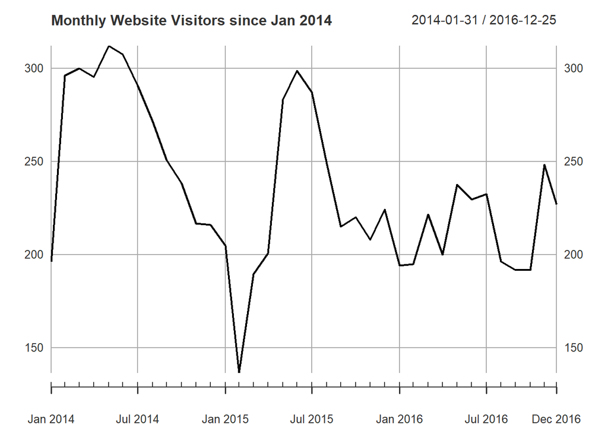

```r
plot(webtfm, main="Monthly Website Visitors since Jan 2014")
```

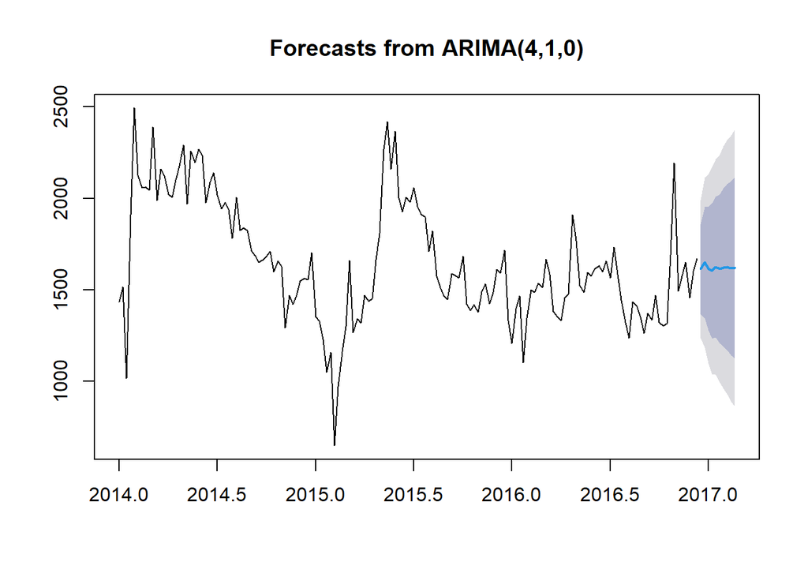

```r
webts <- ts(webtfw, start=c(2014,01,19), frequency=52)
plot(forecast(auto.arima(webts), h=10))
```

Another tip I want to give you is on the use of `quantmod` to extract stock data. R’s `quantmod` package made this a breeze. When I execute the following code chunk, an object named `AAPL` will be created containing the stock we specified through the symbol:

```r
options("getSymbols.warning4.0"=FALSE)
library(quantmod)
start <- as.Date("2014-09-10")
end <- as.Date("2018-09-09")

# Let's get Apple stock data; Apple's ticker symbol is AAPL. We use the
# quantmod function getSymbols, and pass a string as a first argument to
# identify the desired ticker symbol, pass 'yahoo' to src for Yahoo!
# Finance, and from and to specify date ranges

# The default behavior for getSymbols is to load data silently (and directly) into the
# global environment, with the object being named after the loaded ticker
# symbol.

getSymbols("AAPL", src = "yahoo", from = start, to = end)
```

Taking a peek at the data:

```r
head(AAPL, 8)
```

[output not shown]

```r
apl <- as.ts(AAPL[,1])
plot(apl)
```

[output not shown]

Now that we’ve learned about moving averages, let’s do a fun practice of adding a SMA to our bar plot. Recall that the bigger `n` is for moving averages, the smoother the line:

```r
barChart(AAPL, theme='white.mono')
addSMA(n=15, col = "goldenrod4")
```

[output not shown]

One last tip: When you plot a multivariate time series earlier, it plots each time series separately (`plot.type="multiple"`) but if you prefer to have time plotting as a single plot, you can specify that:

```r
## Multivariate
z <- ts(matrix(rnorm(300), 100, 3), start = c(1961, 1), frequency = 12)
class(z)
```

```
## [1] "mts"    "ts"     "matrix" "array"
```

```r
head(z) # as "matrix"
```

```
##             Series 1    Series 2   Series 3
## Jan 1961  0.28702358 -1.45894165  0.2626297
## Feb 1961 -2.34830162 -0.66682774 -0.1347249
## Mar 1961  0.06841968 -0.04054716  1.1861595
## Apr 1961 -0.83207285 -1.10910521  0.8621207
## May 1961 -0.61977261  1.13658881  0.7006150
## Jun 1961  0.60477817 -0.06840064 -1.4969924
```

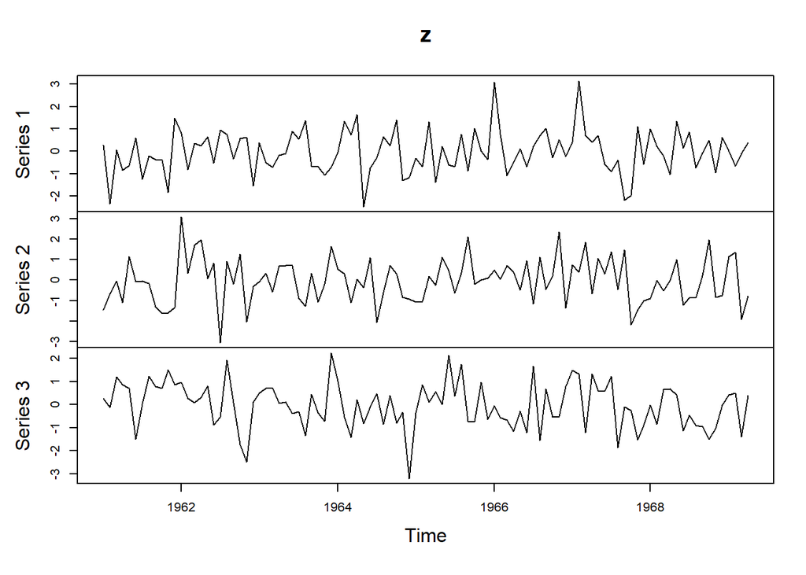

```r
plot(z)
```

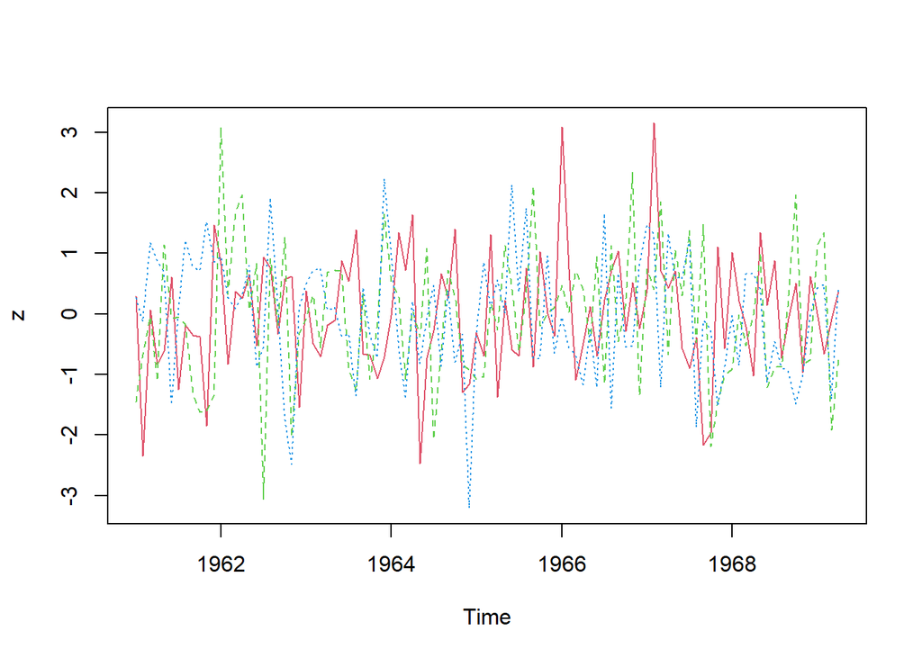

```r
plot(z, plot.type = "single", lty = 1:3, col=2:4)
```

# 4 Graded Quizzes

This section of the workshop needs to be completed in the classroom in order to obtain a score that count towards your final grade.

# 5 Learn-by-Building

This week’s learn-by-building may require a non-trivial amount of pre-processing so I recommend you schedule extra sessions with your mentor or work in a group if necessary. Download the dataset from [Chicago Crime Portal](https://data.cityofchicago.org/Public-Safety/Crimes-2001-to-present/ijzp-q8t2), and use a sample of these data to build a forecasting project where you inspect the seasonality and trend of crime in Chicago. Submit you project in the form of a RMD format, and address the following question:

- Is crime generally rising in Chicago in the past decade (last 10 years)?
- Is there a seasonal component to the crime rate?
- Which time series method seems to capture the variation in your time series better? Explain your choice of algorithm and its key assumptions

Student should be awarded the full (3) points if they address at least 2 of the above questions. The questions are by no means definitive, but can be used as a “guide” in the preparation of your project. The data contains a variety of offenses, but you can sample only a type of crime you’re interested in (eg. theft, narcotic, battery etc). Use visualization if it helps support your narrative.

Alternatively, read on in the Extra Content and peek at the `wiki.R` script that I gave. Adjust the script to scrap some data relating to Wikipedia views on any subject that you are interested in (choose between the English or Bahasa Indonesia version of Wikipedia). Produce a well-formatted RMD report that outline your findings and forecasts. Use any forecasting or time series method and argue your case. Show at least 1 visualization to complement your writing.

Student should be awarded the full (3) points if the report displays: - Appropriate use of any time series method  
- Visualization  
- Analysis on the trend (are more people interested in that subject over time? Are people reading about data science algorithms on Monday the most? Are Indonesians considerably more interested in the history and definition of Bhinneka Tunggal Ika as we near Independence Day each year?) Show originality and your own analysis / opinion on the matter supported by a simple visualization of the trend.

# 6 Annotations

[^1]: T. Raicharoen, C.Lursinsap, P. Sanguanbhoki, *Application of critical support vector machine to time series prediction*
[^2]: G.E.P. Box, G.Jenkins, *Time Series Analysis, Forecasting and Control*
[^3]: G.P. Zhang, *Time Series forecasting using a hybrid ARIMA and neural network model*
[^4]: R Documentation, Time Series Object
[^5]: World Development Indicators, The World Bank DataBank. Retrieved 30/6/2017
[^6]: [Lyndon Johnson left office as a deeply unpopular president. So why is he so admired today?](https://www.washingtonpost.com/news/made-by-history/wp/2018/03/30/lyndon-johnson-left-office-as-a-deeply-unpopular-president-so-why-is-he-so-admired-today/)
[^7]: Answer for Dive Deeper, because it’s an additive model your random components are `births_ts - trn - ssnl`; Say it’s a multiplicative model you would use `births_ts / trn / ssnl`
[^8]: Duke University, [Statistical forecasting: notes on regression and time series analysis](https://people.duke.edu/~rnau/411mean.htm#top)
[^9]: [Tannyasharma, *Comparison Stydu of ADF vs KPSS test*](https://medium.com/@tannyasharma21/comparision-study-of-adf-vs-kpss-test-c9d8dec4f62a)